# Module 12 Lecture - Social & Industrial-Organizational Psychology

Introductory Psychology

Quinton Quagliano, M.S., C.S.P

Department of Psychology

# 1 Overview and Introduction

Agenda

1 Overview and Introduction

2 Overview of Social Psychology

3 Self-presentation

4 Overview of Industrial-Organizational Psychology

5 Organizational Psychology: The Social Dimension of Work

6 Conclusion

## 1.1 Textbook Learning Objectives

- Define social psychology
- Describe situational versus dispositional influences on behavior
- Describe the fundamental attribution error
- Explain actor-observer bias
- Describe self-serving bias
- Explain the just-world hypothesis
- Describe social roles and how they influence behavior
- Explain what social norms are and how they influence behavior
- Define script
- Define conformity and types of social influence
- Understand the scope of study in the field of industrial and organizational psychology
- Define organizational psychology
- Explain the significance of organizational culture

## 1.2 Instructor Learning Objectives

- Understand the respective scopes and interests of social and industrial-organizational psychology
- Be able to classify a study as being related to one of these domains
- Understand industrial-organizational psychology as an extension and connection to social psychology
- Appreciate the real-world importance of both sub-areas

## 1.3 Introduction

- **Social Psychology** is the modern sub-field of psychology focused upon social group behaviors and how our behaviors, thoughts, and feelings are socially driven
  - Example: Why do people take no action when they hear a cry for help, when they are in a group? Why do people act different when among different groups (friends vs strangers)?
- **Industrial-Organization (IO) Psychology** is a modern subfield of psychology focused mostly on how the science of examining human behavior applies to the workplace and our relationships within it
  - Example: Why do certain management styles improve or hurt performance? Why do people perform more effectively when working from home than working from an office?
- **Discuss: Using the examples above, see if you can make another 2 examples of studies that might fall under the broad umbrella of social psychology and IO psychology (make one example for each)**
- These two areas have a lot of overlap, because we are often social in our workplace! A lot of prominent social psychologists end up creating theories that are relevant to work, success, and productivity
  - We are going to take a look at some the core, well-established phenomena in each of these areas - but there is much that we won’t touch on! Read your book for additional ideas if you are interested
- **Important: Both of these areas have vast amounts of misinformation and/or misunderstanding; be cautious in applying these concepts to real scenarios**

# 2 Overview of Social Psychology

Agenda

1 Overview and Introduction

2 Overview of Social Psychology

3 Self-presentation

4 Overview of Industrial-Organizational Psychology

5 Organizational Psychology: The Social Dimension of Work

6 Conclusion

## 2.1 Introduction

- According to the APA, social psychologists:

> “are interested in all aspects of personality and social interaction, exploring the influence of interpersonal and group relationships on human behavior.”
- Social psychologists broadly look at both intrapersonal and interpersonal levels of thinking and behavior
  - **Intrapersonal** is focused upon individual thoughts, feelings, and actions
  - Whereas, **Interpersonal** is the focus on group-level behaviors and trends
  - Across these areas, psychologists want to understand how our social nature lends to how we think, feel, and act
    - Yes, even the introverts still have social actions!
- **Important: While there are studies done on animal socializing - most of 'social psychology' as a field is focused upon humans.**

## 2.2 Situational and Dispositional Influences on Behavior

- As usual, us psychologists are interested in why something happens the way it does, e.g., why do we do that thing? why do we act in that way? why do we think that?
- Social psychologists, traditionally, had two perspectives: situationism and dispositionism
  - The perspective of **situationism** holds that our actions are mostly a result of our situation, context, and environment
  - Alternatively, the perspective of **dispositionism** holds that our actions are mostly rooted in our personality and temperament
  - At times, there has been conflict between these perspectives, but many psychologists now would agree that our actions are a result of both our internal personality, and the situation we are in
- **Discuss: Disagreement between theories that might both be partially true is fairly common in psychology. As review, what two theories of our auditory sense are both somewhat accurate in describing our ability to discriminate between different pitches? hint: they relate to hair cells in the cochlea**
- **Question: Cheri lashes out at her friends due to a prank (at her expense) that ruined the organization of her workplace. What might Freud say about why Cheri does this?**
- A) She is fixated in the anal stage
- B) She is fixated in the phallic stage
- C) She is surrounded by jerks, and feels like the only sane person
- D) She is not accepted among her colleagues, and thus they treat her worse, leading to resentment

## 2.3 Fundamental Attribution Error

- Especially in Western, **individualistic cultures**, like in the US, our society as a whole is biased towards the dispositionism approach
  - However, this may erroneously lead to an assumption that a misdeed or negative action is due to a personal moral or personality failing
  - Our process of determining where we place “fault” is called **attribution**
  - E.g.:
    - That person who is financially poor is so because they lack hard work
    - My professor is just vindictive, and that’s why they give low grades
    - That person who cut me off on the road is reckless, careless, and a selfish person
    - That thief stole the baby formula because they are greedy and want to sell it
- **Question: Consider this scenario: someone wants to find a job and employment, but keeps getting in trouble for stealing food - which personality theorist might say this person is unable to find security because their basic need for food is not yet met?**
- A) Abraham Maslow
- B) Sigmung Freud
- C) Jean Piaget
- D) Alfred Adler
- All of these prior examples attribute actions to a person’s disposition
- **Important: To be clear: it is quite possible these things are true, BUT, this assumption is not always correct**
- However, this uncharitable tendency to “assume the worst” about people can be wrong to attribute the failing to the disposition of the person, rather than the circumstances
  - This is called the **fundamental attribution error**
  - From examples before:
    - That person who is financially poor may have had a major medical accident and been unjustly fired from their job
    - My professor teaches a naturally hard class, and has to grade at a high level to make sure we are well-prepared, even if that results in a lower grade
    - There are both situational attributions
- **Discuss: Consider the other two examples from before, how could you 'turn around' those stories to represent a circumstance leading to this result**
- On the flip side, it seems that **collectivist culture**, or that which emphasizes the group and broader community appear to be more biased toward a situational perspective
  - Cross-cultural studies appear to suggest that people in collectivist cultures are less prone to the fundamental attribution error
- **Discuss: Consider this scenario: You see a man pull into a parking lot at a high speed, and quickly pull into handicap spot, when he is lacking a placard for it. Write both a dispositional and situational assessment of this man's behavior**
- Sometimes the fundamental attribution error can manifest as selectively remembering certain parts of a person’s actions
- **Question: Which type of memory is most related to our memories of events as they occur?**
- A) Episodic memory
- B) Procedural memory
- C) Anecdotal memory
- D) Short-term memory

## 2.4 Actor-Observer Bias

- **Important: We are often generous to ourselves, but less so to others - be mindful of how readily you jump to assumptions, and also mindful of how often you 'make excuses' based on your circumstances**
- The **actor-observer bias** is our tendency to assume that others actions are primarily a result of their disposition, while our actions are mostly situational

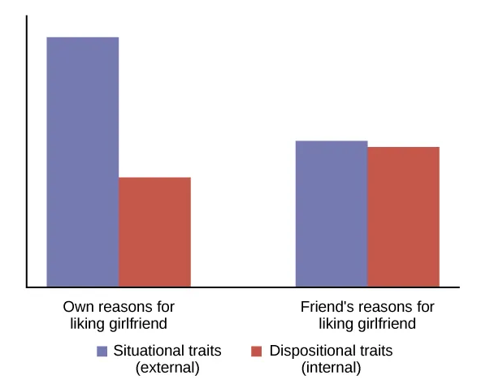

- **Question: I catch a student cheating on a piece of homework - which personality theorist would say they say it's because they feel inferior to their peers and just wanted to turn in work as good as the other students?**
- A) Abraham Maslow
- B) Sigmung Freud
- C) Jean Piaget
- D) Alfred Adler

## 2.5 Self-Serving Bias

- The **self-serving bias** can almost be thought of as an opposite to the actor-observer bias
  - This is where we prefer to attribute our successes to our internal traits, but our failures to situational circumstances
  - This also extends to those that we like, such as close friends and family
- **Important: Sometimes our defense of our friends can be pretty misguided.**
- **Discuss: Consider the scenario in which your favorite sports team wins or loses. What sorts of things are you likely to say about *why* they won or loss?**
- **Question: Which theory of motivation suggests we are motivated to behaviors, in part, for a sense of achievement?**
- A) Drive theory
- B) Instinctual theory
- C) Hierarchy of needs
- D) Social motivation

## 2.6 Just-World Hypothesis

- The **Just-World Hypothesis** is the somewhat inaccurate belief that good things happen to good people, and bad things happen to bad people.
- Unfortunately, one negative consequence of this belief, is that we tend to shift our opinion of people based upon their circumstances they suffer from, often described as victim-blaming
  - This bad thing happened to you $\rightarrow$ you must have deserved it somehow
  - E.g., negative opinions of those who have been diagnosed with AIDS, suffered domestic abuse, suffered homelessness
  - Example: Instructor’s partner
- **Discuss: Do you think the world is just, as this hypothesis states?**

# 3 Self-presentation

Agenda

1 Overview and Introduction

2 Overview of Social Psychology

3 Self-presentation

4 Overview of Industrial-Organizational Psychology

5 Organizational Psychology: The Social Dimension of Work

6 Conclusion

## 3.1 Introduction

- **Important: Even if you don't realize it, our environment almost always plays a role in what we do and how we act**
- The previous section, we focused much on how we perceive and understand the world around us, but we also change how we present to the world

## 3.2 Social Roles

- Each of us have a set of different **social roles**
  - E.g., I am an instructor, a psychometrist, a partner, a brother, a son, etc.
  - For each of these roles, there is an expected set of behaviors, mannerisms, language, etc.
  - It is normal for us to change our behaviors based upon what role we are currently “in”
- **Discuss: Think about the sort of roles you fulfill, and list them out, like I just did**

## 3.3 Social Norms

- A **social norm** is a set of expectations that a group or community has for it’s members
  - Transgressing against the norms can cause a person to be removed or ostracized from a group
  - One of the most stressful experiences can be not being aware of the norms to follow - common in culture shock!
- **Discuss: Think about when you are sitting in a lecture class, what sort of unspoken expectations are there about how you ought to behave?**

## 3.4 Scripts

- **Scripts** are our knowledge how we “ought to” act and behave in a certain scenario
  - Example: when you go to order food at a fast food counter, you’ll greet the cashier, state what things you want to order, hand over your payment, get a receipt, and then wait nearby for your food
- Scripts can be *very* culture-dependent, and one might be surprised when a script “doesn’t work’!
- **Discuss: Think about a time that you didn't have a script for a scenario and felt like a 'fish out of water'**

# 4 Overview of Industrial-Organizational Psychology

Agenda

1 Overview and Introduction

2 Overview of Social Psychology

3 Self-presentation

4 Overview of Industrial-Organizational Psychology

5 Organizational Psychology: The Social Dimension of Work

6 Conclusion

## 4.1 Introduction and Subtypes

- Industrial-organization, or IO, psychology, is all about how humans think, act, and behave at work!
  - I like to think of it as a part of social psychology, because it often involves understanding how people act as part of groups, and how that contributes to work
  - There are 3 divisions within this: industrial psychology, organizational psychology, and human factors psychology
- **Industrial psychology** is all focused on understanding “fit” to jobs and how one is evaluate and performs within that job
  - Example: A study on how certain personality types or levels of extraversion predict better performance in a high-stakes sales roles
- **Organizational psychology** focuses on different group dynamics, cultures, toxicity, and management in the workplace
  - Example: A study on how more permissive or authoritative workplace management changes conversations and frequency of messaging
- **Human factors psychology** is then focused on how employees interact with their workspace and tools
  - Example: A study on how workplace ergonomics affects worker productivity and focus
- **Question: A researcher is looking at how a new desk design and mousepad reduce repetitive stress injuries among programmers**
- A) Industrial psychology
- B) Organizational psychology
- C) Human factors psychology
- D) None of the above

# 5 Organizational Psychology: The Social Dimension of Work

Agenda

1 Overview and Introduction

2 Overview of Social Psychology

3 Self-presentation

4 Overview of Industrial-Organizational Psychology

5 Organizational Psychology: The Social Dimension of Work

6 Conclusion

## 5.1 Introduction

- This subarea of IO psychology is the most closely related to social psychology, so it ties into what we talk through in those sections
- We will walk through several of the social aspects of the workplace and occupations

## 5.2 Job Satisfaction

- **Job satisfaction** is how content we feel about the nature of work, and our job
  - It can be a complex relationship between our personality, the people we work with, and the nature of our work that determines if we feel satisfied or not
  - Satisfaction is both cognitive and emotional, as it might manifest both as a sense of feeling fulfilled intellectually while not being overwhelmed
- **Discuss: If you are working a job, or have worked one, think of one thing that has made you feel more satisfied with your job, and something that has made you feel less satisfied.**

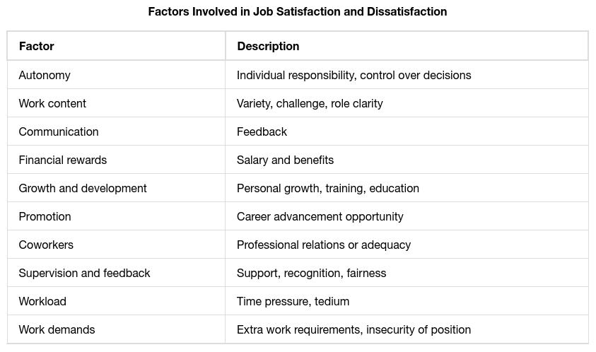

## 5.3 Work-Family Balance

- **Work-family balance** is the way that work helps and harms the time we are able to spend at time home versus the time at work.
- Because work takes up so much of our lives, there are several ways that conflict might arise
  - Time devoted to work makes it difficult to fulfill requirements of family, or vice versa,
  - Strain from participation in work makes it difficult to fulfill requirements of family, or vice versa, and
  - Specific behaviors required by work make it difficult to fulfill the requirements of family, or vice versa.

## 5.4 Organizational Culture

- **Discuss: If you are working a job, or have worked one, how would you intuitively describe the 'culture' of your workplace?**
- **Organizational culture** is a pretty broad term to describe:
  - Values
  - Visions/mission
  - Interactions among employees
- Some departments or individual units within the organization, may have distinct or individual cultures that are different than the larger organization

# 6 Conclusion

Agenda

1 Overview and Introduction

2 Overview of Social Psychology

3 Self-presentation

4 Overview of Industrial-Organizational Psychology

5 Organizational Psychology: The Social Dimension of Work

6 Conclusion

## 6.1 Recap

- Humans are social creatures, and much of our lives are spent in the presence of other people, and thus, much of our time is spent adapting our behaviors, emotions, and thoughts to our social context
- We have a complicated way of dealing with the myriad of social situations we find ourselves in, and we also make a lot of judgements on other individuals and their actions. But we can run into many biases and problems in these judgements
- Work is a large, important part of our life and IO psychology gives us some insight and language to describe the science of working and what makes it good and bad

## 6.2 Lecture Check-in

- Make sure to complete any lecture check-in tasks associated with this lecture!

[figure not shown]

Module 12 Lecture - Social & Industrial-Organizational Psychology || Introductory Psychology